# Velocity model v0.4.2: v0.4.1 without self-paired differential times (D-B099)

v0.4.1 (re-timed picks, D-B081 floor in the inversion) with the self-paired catalog differential times of the mendocino_gorda_c, blanco and washington tiles removed (8 events paired with themselves, read by tomoDD as absolute times of 0 s) and those tiles re-inverted with the patched tomoDD-SE (stable sph2car/car2sph near the tile centre axis), D-B099; product as D-B076: medium (rock / water / air at the D-B068 merged surface), D-B073 shallow-crust node rule, Vp_tomography / Vs_tomography = the inversion values. Generated by workflow/10_tomography/b2_v042_analyse.py (branch tomo/ensemble-fix). Staged, not registered.

## Summary

- Freeze 2026-11-26 (/wd1/mdenolle_data/tomo_v1/src/frozen_2026-11-26_inv/bin): the v0.4.1 runs below reproduced byte for byte (5 of 5 runs with no differing output file).
- Inputs: the three rebuilt tiles equal v0.4.1's minus exactly the self-pair blocks (6 of 6 datasets incl. the noise-floor copies); every other input byte-identical.
- Model: resolved-node rms change Vp 0.8274 % (noise floors 0.7125 / 0.8394), 0 nodes above 2x the local noise, Vs 1.3882 % (noise floors 0.9887 / 0.8692), 21 nodes above 2x the local noise, VpVs 0.0284 (noise floors 0.0214 / 0.0222), 5 nodes above 2x the local noise.
- Self-paired events: separation from their co-located twins v0.4.1 -> v0.4.2 (km): 81324/78249 14.38 -> 1.57, 156844/151664 dropped -> 0.37, 28514/155252 13.58 -> 2.6, 40700/103477 17.93 -> 0.66, 53148/61276 dropped -> 2.59, 53148/94266 dropped -> 3.53, 55170/29138 dropped -> 0.86, 80094/28661 26.58 -> 1.75, 94266/53148 dropped -> 3.53, 94266/61276 dropped -> 0.96.
- Events kept: mendocino_gorda_c 12190 -> 12191 of 12191, blanco 4378 -> 4378 of 4378, washington 9329 -> 9332 of 9332 (v0.4.1 had dropped 4 of the self-paired events).
- Final hypocentres above the true surface in v0.4.2: 0; air quakes 0.

## 1. Freeze identity

v0.4.1 deterministic runs rerun with the 2026-11-26 binary of the same size class, same inputs, tomoDD-SE.inp, MOD and surface.dat; Output_Files compared with cmp (partial runs: tomoDD.loc, the first iterations' tomoDD.reloc.001.00N and tomoDD-SE.res.ini). tomoDD-SE.log differs in text only (timestamps).

| run | binary | binary_md5 | exit | files_compared | different | log_text_differs | wall_min |
| --- | --- | --- | --- | --- | --- | --- | --- |
| blanco_m0f_d200_s20 | tomoDD-SE_e10k | de563b4ca49b | exit 0 | 21 | [] | True | 9.6 |
| margin_m0_v4_d200_s480 | tomoDD-SE_m | 7e35e87e3111 | exit 0 | 21 | [] | True | 14.6 |
| mendocino_gorda_c_m0f_d200_s480 | tomoDD-SE_e13k | 1b3e92d56f90 | stopped after 3 iterations (rc 143) | 5 | [] | True |  |
| oregon_m0f_d200_s480 | tomoDD-SE_e10k | de563b4ca49b | exit 0 | 21 | [] | True | 9.7 |
| washington_m0f_d200_s480 | tomoDD-SE_w | 19c2fb1b4a0e | stopped after 3 iterations (rc 143) | 5 | [] | True |  |

## 2. Inputs of the rebuilt tiles

| new | old | checked | problems | identical_files | dt_equals_old_minus_self_pairs | self_pairs_removed | data_lines_removed | pairs_old_new | data_old_new | self_pairs_left |
| --- | --- | --- | --- | --- | --- | --- | --- | --- | --- | --- |
| mendocino_gorda_c_m0g | mendocino_gorda_c_m0f | True | [] | 10 | True | [156844] | 26 | [44362, 44361] | [651518, 651492] | [] |
| mendocino_gorda_c_m0gnf | mendocino_gorda_c_m0fnf | True | [] | 10 | True | [156844] | 26 | [44362, 44361] | [651518, 651492] | [] |
| blanco_m0g | blanco_m0f | True | [] | 10 | True | [81324] | 13 | [19992, 19991] | [300516, 300503] | [] |
| blanco_m0gnf | blanco_m0fnf | True | [] | 10 | True | [81324] | 13 | [19992, 19991] | [300516, 300503] | [] |
| washington_m0g | washington_m0f | True | [] | 10 | True | [28514, 40700, 53148, 55170, 80094, 94266] | 99 | [40539, 40533] | [811641, 811542] | [] |
| washington_m0gnf | washington_m0fnf | True | [] | 10 | True | [28514, 40700, 53148, 55170, 80094, 94266] | 99 | [40539, 40533] | [811641, 811542] | [] |

## 3. Model v0.4.2 - v0.4.1 (merged inversion values)

Resolved = checkerboard-resolved nodes (D-B049 masks; identical in both: True); tile-covered = inside a merged tile's box. Vp, Vs in percent, Vp/Vs absolute. Noise floors: each chain rerun with N(0, 1e-6 s) on every observed time and merged with the same rules (v0.4.2nf: M0 and oregon noise runs of v0.4.1, the three rebuilt tiles rerun). above_noise = |difference| > 2 x the largest |noise difference| (either chain) at the node and its 26 neighbours.

| quantity | unit | nodes | depth_km | n_nodes | rms | max_abs | changed_nodes | noise_v042_rms | noise_v041_rms | noise_max_abs | above_noise_nodes | above_noise_pct |
| --- | --- | --- | --- | --- | --- | --- | --- | --- | --- | --- | --- | --- |
| Vp | pct | resolved | all | 888 | 0.8274 | 6.147 | 758 | 0.7125 | 0.8394 | 9.103 | 0 | 0 |
| Vs | pct | resolved | all | 320 | 1.388 | 8.162 | 294 | 0.9887 | 0.8692 | 8.888 | 21 | 6.56 |
| VpVs | abs | resolved | all | 255 | 0.0284 | 0.1285 | 252 | 0.0214 | 0.0222 | 0.1202 | 5 | 1.96 |
| Vp | pct | tile-covered | all | 94656 | 0.0996 | 6.147 | 16647 | 0.1292 | 0.1395 | 10.28 | 194 | 0.2 |
| Vs | pct | tile-covered | all | 94626 | 0.0931 | 8.162 | 1853 | 0.0777 | 0.0651 | 9.276 | 118 | 0.12 |
| VpVs | abs | tile-covered | all | 94557 | 0.0019 | 0.1285 | 16607 | 0.0023 | 0.0023 | 0.2058 | 158 | 0.17 |

| quantity | unit | nodes | depth_km | n_nodes | rms | max_abs | changed_nodes | noise_v042_rms | noise_v041_rms | noise_max_abs | above_noise_nodes | above_noise_pct |
| --- | --- | --- | --- | --- | --- | --- | --- | --- | --- | --- | --- | --- |
| Vp | pct | resolved | 1 | 20 | 0.0104 | 0.0205 | 13 | 0.0149 | 0.0191 | 0.0338 | 0 | 0 |
| Vp | pct | resolved | 3 | 38 | 0.0096 | 0.0193 | 29 | 0.0145 | 0.0124 | 0.0434 | 0 | 0 |
| Vp | pct | resolved | 5 | 51 | 0.0103 | 0.0239 | 41 | 0.0116 | 0.0145 | 0.0349 | 0 | 0 |
| Vp | pct | resolved | 7 | 52 | 0.0261 | 0.1124 | 46 | 0.0157 | 0.0331 | 0.1371 | 0 | 0 |
| Vp | pct | resolved | 9 | 21 | 0.0279 | 0.0606 | 20 | 0.0101 | 0.0148 | 0.0299 | 0 | 0 |
| Vp | pct | resolved | 12 | 4 | 0.0167 | 0.0286 | 4 | 0.0064 | 0.0167 | 0.0223 | 0 | 0 |
| Vp | pct | resolved | 15 | 256 | 0.8743 | 4.541 | 226 | 0.801 | 0.7294 | 4.92 | 0 | 0 |
| Vp | pct | resolved | 18 | 313 | 0.9375 | 6.038 | 293 | 0.7623 | 0.7912 | 5.029 | 0 | 0 |
| Vp | pct | resolved | 29 | 133 | 1.015 | 6.147 | 86 | 0.8872 | 1.486 | 9.103 | 0 | 0 |
| Vs | pct | resolved | 7 | 1 | 0.0428 | 0.0428 | 1 | 0.107 | 0.0214 | 0.107 | 0 | 0 |
| Vs | pct | resolved | 12 | 1 | 0.6904 | 0.6904 | 1 | 0.1133 | 0.1074 | 0.1133 | 0 | 0 |
| Vs | pct | resolved | 15 | 188 | 1.392 | 8.162 | 171 | 1.042 | 0.6059 | 8.888 | 18 | 9.57 |
| Vs | pct | resolved | 18 | 110 | 1.498 | 7.676 | 105 | 0.8757 | 1.108 | 7.676 | 3 | 2.73 |
| Vs | pct | resolved | 29 | 20 | 0.5139 | 1.601 | 16 | 1.098 | 1.374 | 4.945 | 0 | 0 |
| VpVs | abs | resolved | 15 | 148 | 0.0261 | 0.1109 | 147 | 0.0194 | 0.016 | 0.095 | 3 | 2.03 |
| VpVs | abs | resolved | 18 | 87 | 0.0301 | 0.1285 | 87 | 0.0238 | 0.0223 | 0.1043 | 2 | 2.3 |
| VpVs | abs | resolved | 29 | 20 | 0.0362 | 0.112 | 18 | 0.025 | 0.0469 | 0.1202 | 0 | 0 |
| Vp | pct | tile-covered | -3 | 4484 | 0.0017 | 0.0951 | 31 | 0.0091 | 0.0092 | 0.5611 | 0 | 0 |
| Vp | pct | tile-covered | -1 | 4484 | 0.0108 | 0.2422 | 429 | 0.0124 | 0.014 | 0.4295 | 14 | 0.31 |
| Vp | pct | tile-covered | 1 | 4484 | 0.0263 | 1.584 | 651 | 0.0162 | 0.0191 | 0.6298 | 15 | 0.33 |
| Vp | pct | tile-covered | 3 | 4484 | 0.0362 | 1.01 | 778 | 0.292 | 0.2875 | 7.503 | 10 | 0.22 |
| Vp | pct | tile-covered | 5 | 4484 | 0.0258 | 0.5713 | 878 | 0.0709 | 0.0596 | 2.673 | 18 | 0.4 |
| Vp | pct | tile-covered | 7 | 4484 | 0.0265 | 0.634 | 946 | 0.1198 | 0.0786 | 3.936 | 28 | 0.62 |
| Vp | pct | tile-covered | 9 | 4484 | 0.0546 | 2.158 | 1038 | 0.113 | 0.1009 | 3.636 | 52 | 1.16 |
| Vp | pct | tile-covered | 12 | 4484 | 0.1003 | 4.628 | 1148 | 0.0701 | 0.1027 | 4.271 | 33 | 0.74 |
| Vp | pct | tile-covered | 15 | 4705 | 0.2171 | 4.541 | 1393 | 0.1983 | 0.1832 | 4.92 | 6 | 0.13 |
| Vp | pct | tile-covered | 18 | 4677 | 0.2564 | 6.038 | 1444 | 0.2209 | 0.2284 | 5.029 | 7 | 0.15 |
| Vp | pct | tile-covered | 21 | 4484 | 0.1214 | 5.059 | 1431 | 0.1144 | 0.1542 | 6.262 | 0 | 0 |
| Vp | pct | tile-covered | 25 | 4484 | 0.1243 | 5.865 | 1410 | 0.118 | 0.1628 | 6.136 | 0 | 0 |
| Vp | pct | tile-covered | 29 | 4562 | 0.1911 | 6.147 | 1442 | 0.252 | 0.3329 | 10.28 | 3 | 0.07 |
| Vp | pct | tile-covered | 34 | 4484 | 0.0763 | 2.528 | 1352 | 0.1658 | 0.1758 | 6.369 | 5 | 0.11 |
| Vp | pct | tile-covered | 40 | 4484 | 0.0324 | 1.009 | 1104 | 0.0837 | 0.0916 | 1.53 | 3 | 0.07 |
| Vp | pct | tile-covered | 47 | 4484 | 0.02 | 0.6615 | 744 | 0.065 | 0.0669 | 0.8494 | 0 | 0 |
| Vp | pct | tile-covered | 55 | 4484 | 0.0065 | 0.2175 | 301 | 0.0825 | 0.0225 | 5.32 | 0 | 0 |
| Vp | pct | tile-covered | 65 | 4484 | 0.0052 | 0.2362 | 114 | 0.0128 | 0.0122 | 0.4812 | 0 | 0 |
| Vp | pct | tile-covered | 80 | 4484 | 0.0004 | 0.0155 | 13 | 0.001 | 0.0009 | 0.0132 | 0 | 0 |
| Vp | pct | tile-covered | 100 | 4484 | 0 | 0 | 0 | 0 | 0 | 0 | 0 | 0 |
| Vp | pct | tile-covered | 125 | 4484 | 0 | 0 | 0 | 0 | 0 | 0 | 0 | 0 |
| Vs | pct | tile-covered | -3 | 4484 | 0 | 0 | 0 | 0.0005 | 0.0005 | 0.0224 | 0 | 0 |
| Vs | pct | tile-covered | -1 | 4484 | 0.0005 | 0.0179 | 8 | 0.0006 | 0.0006 | 0.0225 | 0 | 0 |
| Vs | pct | tile-covered | 1 | 4484 | 0.0033 | 0.1282 | 29 | 0.0028 | 0.0034 | 0.1238 | 8 | 0.18 |
| Vs | pct | tile-covered | 3 | 4484 | 0.0129 | 0.7522 | 47 | 0.0504 | 0.0498 | 2.515 | 6 | 0.13 |
| Vs | pct | tile-covered | 5 | 4484 | 0.0108 | 0.5624 | 71 | 0.016 | 0.0176 | 0.5564 | 19 | 0.42 |
| Vs | pct | tile-covered | 7 | 4491 | 0.0218 | 1.335 | 96 | 0.016 | 0.0242 | 1.335 | 16 | 0.36 |
| Vs | pct | tile-covered | 9 | 4484 | 0.0195 | 0.6636 | 153 | 0.0572 | 0.023 | 3.492 | 11 | 0.25 |
| Vs | pct | tile-covered | 12 | 4491 | 0.1339 | 6.973 | 177 | 0.0891 | 0.0204 | 5.826 | 10 | 0.22 |
| Vs | pct | tile-covered | 15 | 4726 | 0.2816 | 8.162 | 465 | 0.2106 | 0.1247 | 8.888 | 35 | 0.74 |
| Vs | pct | tile-covered | 18 | 4645 | 0.2358 | 7.676 | 373 | 0.1649 | 0.1903 | 7.676 | 10 | 0.22 |
| Vs | pct | tile-covered | 21 | 4484 | 0.0705 | 3.03 | 172 | 0.1506 | 0.0508 | 9.276 | 2 | 0.04 |
| Vs | pct | tile-covered | 25 | 4484 | 0.1208 | 5.865 | 142 | 0.0878 | 0.1383 | 6.136 | 1 | 0.02 |
| Vs | pct | tile-covered | 29 | 4529 | 0.0545 | 2.168 | 98 | 0.0874 | 0.0958 | 4.945 | 0 | 0 |
| Vs | pct | tile-covered | 34 | 4484 | 0.0054 | 0.3557 | 11 | 0.0066 | 0.0076 | 0.357 | 0 | 0 |
| Vs | pct | tile-covered | 40 | 4484 | 0.0048 | 0.2937 | 4 | 0.0033 | 0.0052 | 0.2937 | 0 | 0 |
| Vs | pct | tile-covered | 47 | 4484 | 0.0003 | 0.0188 | 3 | 0.0019 | 0.0019 | 0.0241 | 0 | 0 |
| Vs | pct | tile-covered | 55 | 4484 | 0.0003 | 0.0183 | 3 | 0.0011 | 0.001 | 0.023 | 0 | 0 |
| Vs | pct | tile-covered | 65 | 4484 | 0.0003 | 0.0182 | 1 | 0.0008 | 0.0008 | 0.0225 | 0 | 0 |
| Vs | pct | tile-covered | 80 | 4484 | 0 | 0 | 0 | 0 | 0 | 0 | 0 | 0 |
| Vs | pct | tile-covered | 100 | 4484 | 0 | 0 | 0 | 0.0006 | 0.0006 | 0.0131 | 0 | 0 |
| Vs | pct | tile-covered | 125 | 4484 | 0 | 0 | 0 | 0.0006 | 0.0006 | 0.0131 | 0 | 0 |
| VpVs | abs | tile-covered | -3 | 4484 | 0 | 0.0016 | 31 | 0.0002 | 0.0002 | 0.0099 | 1 | 0.02 |
| VpVs | abs | tile-covered | -1 | 4484 | 0.0002 | 0.0044 | 423 | 0.0002 | 0.0002 | 0.0074 | 12 | 0.27 |
| VpVs | abs | tile-covered | 1 | 4484 | 0.0004 | 0.0261 | 648 | 0.0003 | 0.0003 | 0.0104 | 17 | 0.38 |
| VpVs | abs | tile-covered | 3 | 4484 | 0.0007 | 0.0174 | 778 | 0.0048 | 0.0048 | 0.0984 | 11 | 0.25 |
| VpVs | abs | tile-covered | 5 | 4484 | 0.0005 | 0.0099 | 876 | 0.0012 | 0.001 | 0.0466 | 18 | 0.4 |
| VpVs | abs | tile-covered | 7 | 4484 | 0.0006 | 0.0236 | 950 | 0.002 | 0.0014 | 0.0646 | 21 | 0.47 |
| VpVs | abs | tile-covered | 9 | 4484 | 0.0009 | 0.0356 | 1050 | 0.0017 | 0.0017 | 0.0624 | 27 | 0.6 |
| VpVs | abs | tile-covered | 12 | 4484 | 0.0028 | 0.1047 | 1168 | 0.0017 | 0.0018 | 0.0795 | 12 | 0.27 |
| VpVs | abs | tile-covered | 15 | 4695 | 0.0052 | 0.1109 | 1397 | 0.0037 | 0.0031 | 0.095 | 17 | 0.36 |
| VpVs | abs | tile-covered | 18 | 4621 | 0.0049 | 0.1285 | 1414 | 0.004 | 0.0037 | 0.1043 | 12 | 0.26 |
| VpVs | abs | tile-covered | 21 | 4484 | 0.0016 | 0.0527 | 1423 | 0.0019 | 0.0022 | 0.0944 | 0 | 0 |
| VpVs | abs | tile-covered | 25 | 4484 | 0.0012 | 0.0407 | 1426 | 0.002 | 0.0019 | 0.064 | 0 | 0 |
| VpVs | abs | tile-covered | 29 | 4529 | 0.0031 | 0.112 | 1412 | 0.0046 | 0.0055 | 0.2058 | 3 | 0.07 |
| VpVs | abs | tile-covered | 34 | 4484 | 0.0014 | 0.0442 | 1345 | 0.0029 | 0.0031 | 0.115 | 3 | 0.07 |
| VpVs | abs | tile-covered | 40 | 4484 | 0.0006 | 0.0175 | 1097 | 0.0015 | 0.0016 | 0.0255 | 4 | 0.09 |
| VpVs | abs | tile-covered | 47 | 4484 | 0.0004 | 0.0115 | 742 | 0.0011 | 0.0012 | 0.015 | 0 | 0 |
| VpVs | abs | tile-covered | 55 | 4484 | 0.0001 | 0.0038 | 301 | 0.0014 | 0.0004 | 0.0932 | 0 | 0 |
| VpVs | abs | tile-covered | 65 | 4484 | 0.0001 | 0.004 | 113 | 0.0002 | 0.0002 | 0.0082 | 0 | 0 |
| VpVs | abs | tile-covered | 80 | 4484 | 0 | 0.0003 | 13 | 0 | 0 | 0.0002 | 0 | 0 |
| VpVs | abs | tile-covered | 100 | 4484 | 0 | 0 | 0 | 0 | 0 | 0.0002 | 0 | 0 |
| VpVs | abs | tile-covered | 125 | 4484 | 0 | 0 | 0 | 0 | 0 | 0.0002 | 0 | 0 |

Nodes above the noise, by distance to the nearest self-paired event (start position):

| nodes | quantity | within_30km_of_a_self_paired_event | nodes_above_noise |
| --- | --- | --- | --- |
| resolved | VpVs | False | 2 |
| resolved | VpVs | True | 3 |
| resolved | Vs | False | 11 |
| resolved | Vs | True | 10 |
| tile-covered | Vp | False | 134 |
| tile-covered | Vp | True | 60 |
| tile-covered | VpVs | False | 114 |
| tile-covered | VpVs | True | 44 |
| tile-covered | Vs | False | 51 |
| tile-covered | Vs | True | 67 |

Resolved nodes above the noise, largest first:

| nodes | quantity | depth_km | lat | lon | km_to_nearest_self_paired_event | v041 | v042 | diff |
| --- | --- | --- | --- | --- | --- | --- | --- | --- |
| resolved | Vs | 15 | 44.1 | -129.5 | 17.6 | 4.453 | 4.124 | -7.404 |
| resolved | Vs | 18 | 44.2 | -129.5 | 24.5 | 4.261 | 4.478 | 5.092 |
| resolved | Vs | 18 | 44.1 | -129.9 | 46.5 | 4.099 | 4.276 | 4.326 |
| resolved | Vs | 18 | 44.2 | -129.6 | 31.9 | 4.314 | 4.497 | 4.255 |
| resolved | Vs | 15 | 44 | -129.9 | 46.1 | 4.519 | 4.337 | -4.022 |
| resolved | Vs | 15 | 43.9 | -129.2 | 15.2 | 4.7 | 4.845 | 3.103 |
| resolved | Vs | 15 | 43.9 | -129.5 | 21.7 | 4.471 | 4.336 | -3.021 |
| resolved | Vs | 15 | 44 | -129.6 | 26.2 | 4.564 | 4.699 | 2.953 |
| resolved | Vs | 15 | 44 | -128.8 | 44.2 | 4.048 | 4.151 | 2.534 |
| resolved | Vs | 15 | 44.1 | -129.9 | 46.5 | 4.657 | 4.546 | -2.382 |
| resolved | Vs | 15 | 44 | -128.9 | 34.3 | 4.067 | 4.16 | 2.291 |
| resolved | Vs | 15 | 44.3 | -129.4 | 30.4 | 4.521 | 4.607 | 1.915 |
| resolved | Vs | 15 | 43.9 | -129.6 | 29.8 | 4.207 | 4.278 | 1.688 |
| resolved | Vs | 15 | 44.2 | -129.8 | 40.4 | 4.121 | 4.184 | 1.528 |
| resolved | Vs | 15 | 44.2 | -129.5 | 24.5 | 4.564 | 4.628 | 1.418 |
| resolved | Vs | 15 | 44 | -129.5 | 16.3 | 4.788 | 4.856 | 1.409 |
| resolved | Vs | 15 | 43.8 | -129.1 | 29.4 | 4.575 | 4.514 | -1.32 |
| resolved | Vs | 15 | 44.4 | -130.1 | 77.2 | 4.466 | 4.519 | 1.177 |
| resolved | Vs | 15 | 43.9 | -129.4 | 15.8 | 4.628 | 4.576 | -1.124 |
| resolved | Vs | 15 | 44.1 | -129.8 | 36.6 | 4.755 | 4.704 | -1.08 |
| resolved | Vs | 15 | 44.3 | -129.2 | 30.1 | 4.444 | 4.416 | -0.6306 |
| resolved | VpVs | 18 | 44.1 | -129.9 | 46.5 | 1.927 | 1.798 | -0.1285 |
| resolved | VpVs | 15 | 44.1 | -129.5 | 17.6 | 1.774 | 1.884 | 0.1109 |
| resolved | VpVs | 18 | 44.2 | -129.6 | 31.9 | 1.991 | 1.907 | -0.0836 |
| resolved | VpVs | 15 | 44.2 | -129.4 | 19.6 | 1.756 | 1.687 | -0.0692 |
| resolved | VpVs | 15 | 44.1 | -129.2 | 8.6 | 1.895 | 1.958 | 0.0639 |

Tile-covered nodes above the noise, largest first:

| nodes | quantity | depth_km | lat | lon | km_to_nearest_self_paired_event | v041 | v042 | diff |
| --- | --- | --- | --- | --- | --- | --- | --- | --- |
| tile-covered | Vs | 15 | 44.1 | -129.5 | 17.6 | 4.453 | 4.124 | -7.404 |
| tile-covered | Vs | 18 | 44.2 | -129.5 | 24.5 | 4.261 | 4.478 | 5.092 |
| tile-covered | Vs | 18 | 44.1 | -129.9 | 46.5 | 4.099 | 4.276 | 4.326 |
| tile-covered | Vs | 18 | 44.2 | -129.6 | 31.9 | 4.314 | 4.497 | 4.255 |
| tile-covered | Vs | 15 | 44 | -129.9 | 46.1 | 4.519 | 4.337 | -4.022 |
| tile-covered | Vs | 15 | 43.9 | -129.2 | 15.2 | 4.7 | 4.845 | 3.103 |
| tile-covered | Vs | 15 | 43.9 | -129.5 | 21.7 | 4.471 | 4.336 | -3.021 |
| tile-covered | Vs | 15 | 44 | -129.6 | 26.2 | 4.564 | 4.699 | 2.953 |
| tile-covered | Vs | 15 | 44 | -128.8 | 44.2 | 4.048 | 4.151 | 2.534 |
| tile-covered | Vs | 15 | 44.1 | -129.9 | 46.5 | 4.657 | 4.546 | -2.382 |
| tile-covered | Vs | 15 | 44 | -128.9 | 34.3 | 4.067 | 4.16 | 2.291 |
| tile-covered | Vs | 15 | 44.3 | -129.4 | 30.4 | 4.521 | 4.607 | 1.915 |
| tile-covered | Vs | 15 | 43.9 | -129.6 | 29.8 | 4.207 | 4.278 | 1.688 |
| tile-covered | Vp | 1 | 42.6 | -122.6 | 257.3 | 5.229 | 5.311 | 1.584 |
| tile-covered | Vs | 15 | 44.2 | -129.8 | 40.4 | 4.121 | 4.184 | 1.528 |
| tile-covered | Vs | 15 | 44.2 | -129.5 | 24.5 | 4.564 | 4.628 | 1.418 |
| tile-covered | Vs | 15 | 44 | -129.5 | 16.3 | 4.788 | 4.856 | 1.409 |
| tile-covered | Vs | 15 | 43.8 | -129.1 | 29.4 | 4.575 | 4.514 | -1.32 |
| tile-covered | Vs | 15 | 44.4 | -130.1 | 77.2 | 4.466 | 4.519 | 1.177 |
| tile-covered | Vs | 15 | 44.4 | -129.1 | 43.2 | 4.489 | 4.438 | -1.153 |
| tile-covered | Vs | 15 | 43.9 | -129.4 | 15.8 | 4.628 | 4.576 | -1.124 |
| tile-covered | Vs | 15 | 44.1 | -129.8 | 36.6 | 4.755 | 4.704 | -1.08 |
| tile-covered | Vp | 3 | 40.7 | -126.5 | 192.4 | 5.76 | 5.814 | 0.937 |
| tile-covered | Vs | 15 | 44.3 | -129.2 | 30.1 | 4.444 | 4.416 | -0.6306 |
| tile-covered | Vs | 25 | 48.4 | -124.4 | 140.4 | 3.928 | 3.905 | -0.582 |
| tile-covered | Vs | 15 | 49 | -123.2 | 113.1 | 3.797 | 3.78 | -0.4651 |
| tile-covered | Vp | 9 | 49.4 | -124.4 | 30 | 6.355 | 6.33 | -0.3965 |
| tile-covered | Vs | 15 | 48.2 | -124.4 | 152.3 | 3.62 | 3.607 | -0.3705 |
| tile-covered | Vp | 12 | 49.2 | -124.5 | 51.3 | 6.335 | 6.311 | -0.3694 |
| tile-covered | Vp | 9 | 49.4 | -124.5 | 29.1 | 6.275 | 6.252 | -0.357 |
| tile-covered | Vp | 9 | 49.3 | -124.4 | 40.9 | 6.287 | 6.264 | -0.3531 |
| tile-covered | Vp | 12 | 49 | -124.5 | 73.5 | 6.488 | 6.465 | -0.3514 |
| tile-covered | Vp | 9 | 49.3 | -124.5 | 40.2 | 6.245 | 6.225 | -0.333 |
| tile-covered | Vs | 12 | 40.8 | -125.4 | 99.5 | 3.729 | 3.741 | 0.3327 |
| tile-covered | Vp | 9 | 49.5 | -124.4 | 19.5 | 6.498 | 6.476 | -0.3324 |
| tile-covered | Vp | 12 | 49.1 | -124.5 | 62.4 | 6.366 | 6.345 | -0.3267 |
| tile-covered | Vp | 12 | 49.3 | -124.5 | 40.2 | 6.31 | 6.29 | -0.3201 |
| tile-covered | Vp | 12 | 49 | -124.4 | 73.9 | 6.417 | 6.398 | -0.2992 |
| tile-covered | Vp | 12 | 49.2 | -124.4 | 51.9 | 6.302 | 6.284 | -0.2951 |
| tile-covered | Vp | 12 | 49.3 | -124.4 | 40.9 | 6.316 | 6.297 | -0.2913 |

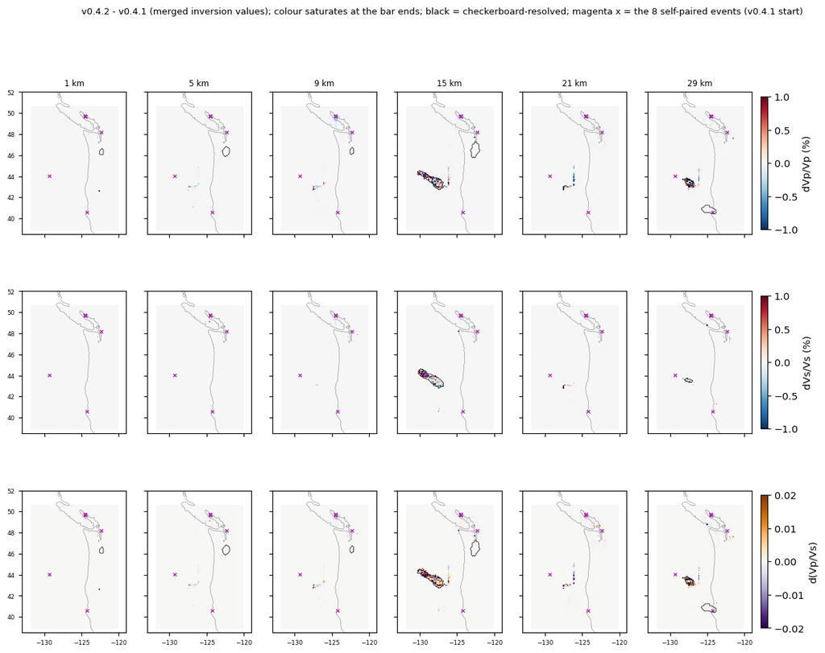

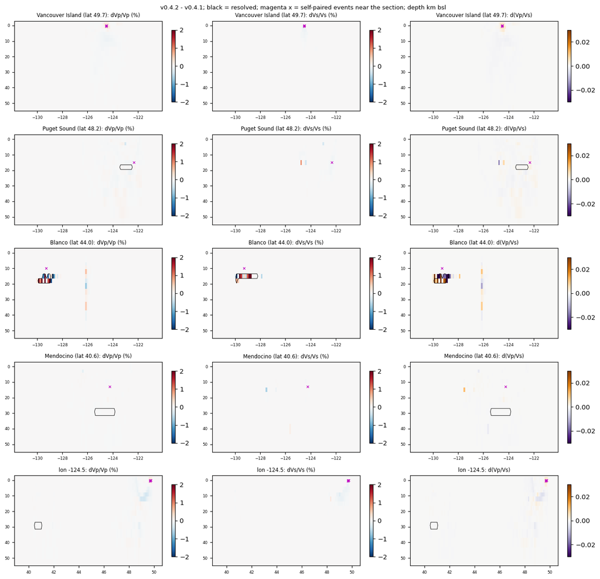

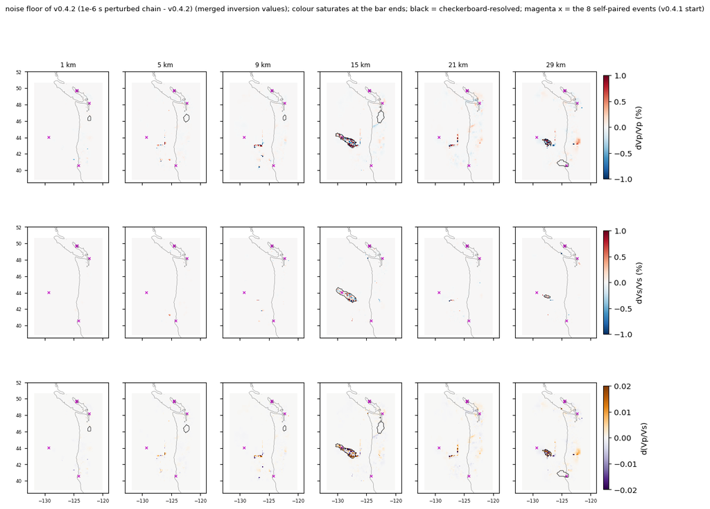

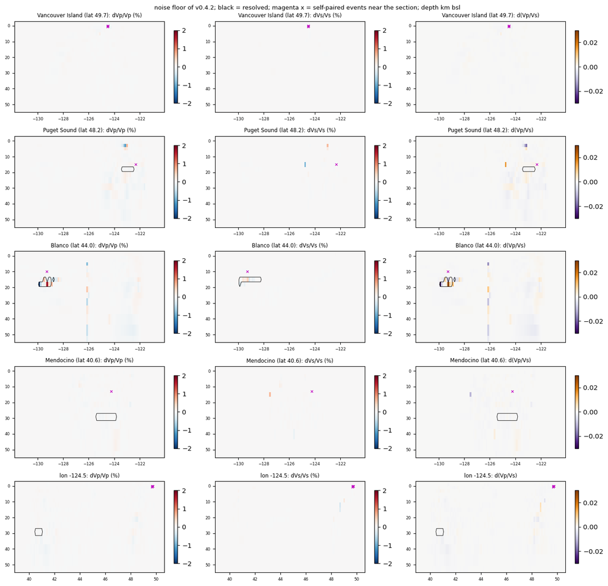

## 4. The self-paired events and their co-located twins

Each self-paired event had a twin with the identical start hypocentre (v4-NLL3D); in v0.4.1 the event's zero-time 'absolute' data pulled it away. Final hypocentres from tomoDD.reloc_geo (true frame).

| stage | self_paired | twin | v041_separation_km | v042_separation_km |
| --- | --- | --- | --- | --- |
| blanco | 81324 | 78249 | 14.38 | 1.57 |
| mendocino_gorda_c | 156844 | 151664 |  | 0.37 |
| washington | 28514 | 155252 | 13.58 | 2.6 |
| washington | 40700 | 103477 | 17.93 | 0.66 |
| washington | 53148 | 61276 |  | 2.59 |
| washington | 53148 | 94266 |  | 3.53 |
| washington | 55170 | 29138 |  | 0.86 |
| washington | 80094 | 28661 | 26.58 | 1.75 |
| washington | 94266 | 53148 |  | 3.53 |
| washington | 94266 | 61276 |  | 0.96 |

| stage | event | role | of | region | start_lat | start_lon | start_depth | v041_lat | v041_lon | v041_depth | v041_from_start_km | v042_lat | v042_lon | v042_depth | v042_from_start_km |
| --- | --- | --- | --- | --- | --- | --- | --- | --- | --- | --- | --- | --- | --- | --- | --- |
| washington | 28514 | self-paired | 28514 | Offshore forearc | 49.66 | -124.5 | 0.0911 | 49.6 | -124.5 | 10.47 | 12.37 | 49.68 | -124.5 | 0.01 | 2.72 |
| washington | 155252 | twin | 28514 | Offshore forearc | 49.66 | -124.5 | 0.0911 | 49.7 | -124.5 | 1.985 | 4.59 | 49.69 | -124.5 | 1.904 | 4.44 |
| washington | 40700 | self-paired | 40700 | Offshore forearc | 49.67 | -124.5 | 0.6445 | 49.61 | -124.4 | 7.786 | 12.38 | 49.7 | -124.6 | 0.152 | 6.6 |
| washington | 103477 | twin | 40700 | Offshore forearc | 49.67 | -124.5 | 0.6445 | 49.73 | -124.6 | 5.256 | 9.16 | 49.7 | -124.6 | 0.152 | 6.28 |
| washington | 53148 | self-paired | 53148 | Offshore forearc | 49.74 | -124.5 | 0.0911 |  |  | dropped |  | 49.76 | -124.5 | 16.32 | 16.39 |
| washington | 61276 | twin | 53148 | Offshore forearc | 49.74 | -124.5 | 0.0911 | 49.75 | -124.5 | 13.32 | 13.39 | 49.75 | -124.5 | 13.87 | 13.91 |
| washington | 94266 | twin | 53148 | Offshore forearc | 49.74 | -124.5 | 0.0911 |  |  | dropped |  | 49.75 | -124.5 | 12.96 | 12.98 |
| washington | 55170 | self-paired | 55170 | Offshore forearc | 49.7 | -124.5 | 0.0911 |  |  | dropped |  | 49.69 | -124.6 | 0.871 | 1.67 |
| washington | 29138 | twin | 55170 | Offshore forearc | 49.7 | -124.5 | 0.0911 | 49.68 | -124.6 | 0.144 | 2.12 | 49.68 | -124.6 | 0.866 | 2.24 |
| washington | 80094 | self-paired | 80094 | Puget/Georgia | 48.19 | -122.3 | 15 | 48.08 | -122.3 | 35.62 | 23.99 | 48.2 | -122.3 | 11.83 | 4.06 |
| washington | 28661 | twin | 80094 | Puget/Georgia | 48.19 | -122.3 | 15 | 48.2 | -122.3 | 13.01 | 2.63 | 48.2 | -122.3 | 12.99 | 2.66 |
| washington | 94266 | self-paired | 94266 | Offshore forearc | 49.74 | -124.5 | 0.0911 |  |  | dropped |  | 49.75 | -124.5 | 12.96 | 12.98 |
| washington | 53148 | twin | 94266 | Offshore forearc | 49.74 | -124.5 | 0.0911 |  |  | dropped |  | 49.76 | -124.5 | 16.32 | 16.39 |
| washington | 61276 | twin | 94266 | Offshore forearc | 49.74 | -124.5 | 0.0911 | 49.75 | -124.5 | 13.32 | 13.39 | 49.75 | -124.5 | 13.87 | 13.91 |
| mendocino_gorda_c | 156844 | self-paired | 156844 | Offshore forearc | 40.61 | -124.2 | 12.82 |  |  | dropped |  | 40.61 | -124.3 | 17.48 | 5.31 |
| mendocino_gorda_c | 151664 | twin | 156844 | Offshore forearc | 40.61 | -124.2 | 12.82 | 40.61 | -124.2 | 17.42 | 5.1 | 40.61 | -124.2 | 17.43 | 5.16 |
| blanco | 81324 | self-paired | 81324 | Blanco | 44.03 | -129.3 | 9.978 | 44.01 | -129.4 | 21.87 | 13.81 | 44.03 | -129.3 | 13.76 | 3.79 |
| blanco | 78249 | twin | 81324 | Blanco | 44.03 | -129.3 | 9.978 | 44.03 | -129.3 | 8.896 | 1.37 | 44.04 | -129.3 | 13.02 | 3.46 |

## 5. Floor stops, air quakes, events above the true surface

| stage | run | rerun | events_start | events_final_v041 | events_final_v042 | floor_lines_v041 | floor_lines_v042 | events_hit_v041 | events_hit_v042 | floor_not_met_v042 | at_floor_final_v041 | at_floor_final_v042 | above_floor_by_more_than_2m_v042 | air_quakes_v042 | iterations_v042 | above_true_surface_final_v041 | above_true_surface_final_v042 | rms_abs_final_v041 | rms_abs_final_v042 |
| --- | --- | --- | --- | --- | --- | --- | --- | --- | --- | --- | --- | --- | --- | --- | --- | --- | --- | --- | --- |
| M0 | margin_m0_v4/d200_s480 | False | 6943 | 6943 | 6943 | 2090 | 2090 | 266 | 266 | 0 | 156 | 156 | 0 | 0 | 12 | 0 | 0 | 0.2819 | 0.2819 |
| mendocino_gorda_c | mendocino_gorda_c_m0g/d200_s480 | True | 12191 | 12190 | 12191 | 503 | 504 | 70 | 70 | 0 | 48 | 48 | 0 | 0 | 12 | 0 | 0 | 0.2413 | 0.2413 |
| blanco | blanco_m0g/d200_s20 | True | 4378 | 4378 | 4378 | 100 | 105 | 21 | 21 | 0 | 11 | 12 | 0 | 0 | 12 | 0 | 0 | 0.2404 | 0.2395 |
| oregon | oregon_m0f/d200_s480 | False | 3390 | 3390 | 3390 | 1724 | 1724 | 218 | 218 | 0 | 125 | 125 | 0 | 0 | 12 | 0 | 0 | 0.1921 | 0.1921 |
| washington | washington_m0g/d200_s480 | True | 9332 | 9329 | 9332 | 2008 | 2047 | 278 | 283 | 0 | 154 | 158 | 0 | 0 | 12 | 0 | 0 | 0.2155 | 0.2156 |

## 6. Hypocentre shifts v0.4.2 - v0.4.1 (rebuilt tiles)

| stage | comparison | region | events | dh_median_km | dh_p90_km | dz_absmedian_km | dz_p90abs_km | max_3d_km | gt1km_3d |
| --- | --- | --- | --- | --- | --- | --- | --- | --- | --- |
| mendocino_gorda_c | v0.4.2 - v0.4.1 | Blanco | 99 | 0.0025 | 0.149 | 0.004 | 0.649 | 3.39 | 10 |
| mendocino_gorda_c | v0.4.2 - v0.4.1 | Gorda | 2467 | 0.0076 | 0.058 | 0.014 | 0.154 | 12.51 | 36 |
| mendocino_gorda_c | v0.4.2 - v0.4.1 | Mendocino | 4047 | 0.0027 | 0.022 | 0.002 | 0.047 | 11.89 | 12 |
| mendocino_gorda_c | v0.4.2 - v0.4.1 | Offshore forearc | 4295 | 0.0039 | 0.026 | 0.004 | 0.046 | 5.96 | 17 |
| mendocino_gorda_c | v0.4.2 - v0.4.1 | Other onshore | 1282 | 0.0017 | 0.012 | 0.002 | 0.036 | 3.41 | 2 |
| mendocino_gorda_c | v0.4.2 - v0.4.1 | all | 12190 | 0.0035 | 0.03 | 0.004 | 0.063 | 12.51 | 77 |
| mendocino_gorda_c | v0.4.2 - v0.4.1 | all but the self-paired events | 12190 | 0.0035 | 0.03 | 0.004 | 0.063 | 12.51 | 77 |
| mendocino_gorda_c | noise floor v0.4.2 (nf - v0.4.2) | Blanco | 99 | 0.0252 | 0.11 | 0.095 | 0.423 | 1.05 | 1 |
| mendocino_gorda_c | noise floor v0.4.2 (nf - v0.4.2) | Gorda | 2467 | 0.0192 | 0.1 | 0.036 | 0.31 | 12.58 | 61 |
| mendocino_gorda_c | noise floor v0.4.2 (nf - v0.4.2) | Mendocino | 4047 | 0.0052 | 0.038 | 0.005 | 0.082 | 9.19 | 24 |
| mendocino_gorda_c | noise floor v0.4.2 (nf - v0.4.2) | Offshore forearc | 4296 | 0.0076 | 0.054 | 0.009 | 0.097 | 5.4 | 35 |
| mendocino_gorda_c | noise floor v0.4.2 (nf - v0.4.2) | Other onshore | 1282 | 0.0063 | 0.029 | 0.008 | 0.072 | 3.82 | 8 |
| mendocino_gorda_c | noise floor v0.4.2 (nf - v0.4.2) | all | 12191 | 0.0081 | 0.057 | 0.01 | 0.132 | 12.58 | 129 |
| mendocino_gorda_c | noise floor v0.4.2 (nf - v0.4.2) | all but the self-paired events | 12190 | 0.0081 | 0.057 | 0.01 | 0.132 | 12.58 | 129 |
| mendocino_gorda_c | noise floor v0.4.1 (nf - v0.4.1) | Blanco | 99 | 0.0329 | 0.16 | 0.084 | 1.184 | 3.22 | 12 |
| mendocino_gorda_c | noise floor v0.4.1 (nf - v0.4.1) | Gorda | 2467 | 0.0189 | 0.098 | 0.037 | 0.314 | 11.98 | 51 |
| mendocino_gorda_c | noise floor v0.4.1 (nf - v0.4.1) | Mendocino | 4047 | 0.0051 | 0.033 | 0.005 | 0.072 | 12.05 | 19 |
| mendocino_gorda_c | noise floor v0.4.1 (nf - v0.4.1) | Offshore forearc | 4295 | 0.0073 | 0.049 | 0.01 | 0.103 | 4.55 | 36 |
| mendocino_gorda_c | noise floor v0.4.1 (nf - v0.4.1) | Other onshore | 1282 | 0.0096 | 0.037 | 0.019 | 0.141 | 3.56 | 4 |
| mendocino_gorda_c | noise floor v0.4.1 (nf - v0.4.1) | all | 12190 | 0.0082 | 0.053 | 0.011 | 0.141 | 12.05 | 122 |
| mendocino_gorda_c | noise floor v0.4.1 (nf - v0.4.1) | all but the self-paired events | 12190 | 0.0082 | 0.053 | 0.011 | 0.141 | 12.05 | 122 |
| blanco | v0.4.2 - v0.4.1 | Blanco | 4214 | 0.0974 | 0.303 | 0.155 | 0.802 | 19.93 | 347 |
| blanco | v0.4.2 - v0.4.1 | Gorda | 3 | 0.1428 | 0.291 | 0.194 | 0.224 | 0.4 | 0 |
| blanco | v0.4.2 - v0.4.1 | JdF ridge/plate | 74 | 0.0318 | 0.155 | 0.02 | 0.108 | 0.46 | 0 |
| blanco | v0.4.2 - v0.4.1 | Offshore forearc | 87 | 0.1459 | 0.438 | 0.167 | 0.877 | 3.76 | 8 |
| blanco | v0.4.2 - v0.4.1 | all | 4378 | 0.0972 | 0.305 | 0.152 | 0.797 | 19.93 | 355 |
| blanco | v0.4.2 - v0.4.1 | all but the self-paired events | 4377 | 0.0972 | 0.305 | 0.152 | 0.796 | 19.93 | 354 |
| blanco | noise floor v0.4.2 (nf - v0.4.2) | Blanco | 4214 | 0.0587 | 0.241 | 0.0845 | 0.527 | 18.75 | 198 |
| blanco | noise floor v0.4.2 (nf - v0.4.2) | Gorda | 3 | 0.1445 | 0.447 | 0.18 | 0.691 | 0.97 | 0 |
| blanco | noise floor v0.4.2 (nf - v0.4.2) | JdF ridge/plate | 74 | 0.0332 | 0.176 | 0.0175 | 0.103 | 1.26 | 1 |
| blanco | noise floor v0.4.2 (nf - v0.4.2) | Offshore forearc | 87 | 0.1299 | 0.421 | 0.152 | 0.669 | 2.05 | 5 |
| blanco | noise floor v0.4.2 (nf - v0.4.2) | all | 4378 | 0.0596 | 0.244 | 0.084 | 0.529 | 18.75 | 204 |
| blanco | noise floor v0.4.2 (nf - v0.4.2) | all but the self-paired events | 4377 | 0.0596 | 0.244 | 0.084 | 0.529 | 18.75 | 204 |
| blanco | noise floor v0.4.1 (nf - v0.4.1) | Blanco | 4214 | 0.0592 | 0.23 | 0.086 | 0.523 | 11.7 | 176 |
| blanco | noise floor v0.4.1 (nf - v0.4.1) | Gorda | 3 | 0.0348 | 0.529 | 0.044 | 0.81 | 1.2 | 1 |
| blanco | noise floor v0.4.1 (nf - v0.4.1) | JdF ridge/plate | 74 | 0.0362 | 0.132 | 0.018 | 0.084 | 0.74 | 0 |
| blanco | noise floor v0.4.1 (nf - v0.4.1) | Offshore forearc | 87 | 0.1411 | 0.454 | 0.2 | 0.886 | 5.38 | 9 |
| blanco | noise floor v0.4.1 (nf - v0.4.1) | all | 4378 | 0.0594 | 0.234 | 0.086 | 0.525 | 11.7 | 186 |
| blanco | noise floor v0.4.1 (nf - v0.4.1) | all but the self-paired events | 4377 | 0.0594 | 0.234 | 0.086 | 0.525 | 11.7 | 186 |
| washington | v0.4.2 - v0.4.1 | Cascades | 1577 | 0.0032 | 0.021 | 0.004 | 0.044 | 1.46 | 9 |
| washington | v0.4.2 - v0.4.1 | Offshore forearc | 1918 | 0.0271 | 0.137 | 0.033 | 0.223 | 18.35 | 31 |
| washington | v0.4.2 - v0.4.1 | Other onshore | 1604 | 0.0038 | 0.028 | 0.005 | 0.066 | 1.52 | 13 |
| washington | v0.4.2 - v0.4.1 | Puget/Georgia | 4230 | 0.0108 | 0.061 | 0.018 | 0.126 | 27.88 | 44 |
| washington | v0.4.2 - v0.4.1 | all | 9329 | 0.0092 | 0.07 | 0.013 | 0.126 | 27.88 | 97 |
| washington | v0.4.2 - v0.4.1 | all but the self-paired events | 9326 | 0.0092 | 0.069 | 0.013 | 0.126 | 8.59 | 94 |
| washington | noise floor v0.4.2 (nf - v0.4.2) | Cascades | 1577 | 0.0029 | 0.02 | 0.003 | 0.05 | 3.52 | 6 |
| washington | noise floor v0.4.2 (nf - v0.4.2) | Offshore forearc | 1921 | 0.0124 | 0.079 | 0.012 | 0.164 | 4.67 | 16 |
| washington | noise floor v0.4.2 (nf - v0.4.2) | Other onshore | 1604 | 0.0046 | 0.028 | 0.006 | 0.064 | 2 | 10 |
| washington | noise floor v0.4.2 (nf - v0.4.2) | Puget/Georgia | 4230 | 0.015 | 0.07 | 0.021 | 0.158 | 6.35 | 56 |
| washington | noise floor v0.4.2 (nf - v0.4.2) | all | 9332 | 0.0097 | 0.057 | 0.011 | 0.13 | 6.35 | 88 |
| washington | noise floor v0.4.2 (nf - v0.4.2) | all but the self-paired events | 9326 | 0.0097 | 0.057 | 0.011 | 0.13 | 6.35 | 88 |
| washington | noise floor v0.4.1 (nf - v0.4.1) | Cascades | 1577 | 0.0044 | 0.026 | 0.005 | 0.055 | 2.25 | 5 |
| washington | noise floor v0.4.1 (nf - v0.4.1) | Offshore forearc | 1918 | 0.012 | 0.068 | 0.016 | 0.154 | 2.93 | 17 |
| washington | noise floor v0.4.1 (nf - v0.4.1) | Other onshore | 1604 | 0.0052 | 0.033 | 0.007 | 0.081 | 1.36 | 3 |
| washington | noise floor v0.4.1 (nf - v0.4.1) | Puget/Georgia | 4230 | 0.015 | 0.072 | 0.02 | 0.148 | 18.56 | 46 |
| washington | noise floor v0.4.1 (nf - v0.4.1) | all | 9329 | 0.0101 | 0.057 | 0.013 | 0.125 | 18.56 | 71 |
| washington | noise floor v0.4.1 (nf - v0.4.1) | all but the self-paired events | 9326 | 0.0101 | 0.057 | 0.013 | 0.125 | 18.56 | 71 |

## 7. Residual rms (final iteration, tomoDD.res)

tomoDD.res holds the last iteration's linearised residuals. v0.4.1's self-pair lines (absolute times of 0 s) are left out of the absolute classes.

| version | stage | phase | cls | v0.4.1 | v0.4.2 | n_v0.4.1 | n_v0.4.2 | change_pct |
| --- | --- | --- | --- | --- | --- | --- | --- | --- |
|  | blanco | P | OBS | 0.1518 | 0.1513 | 4.186e+04 | 4.188e+04 | -0.33 |
|  | blanco | P | all | 0.1518 | 0.1513 | 4.186e+04 | 4.188e+04 | -0.33 |
|  | blanco | S | OBS | 0.2788 | 0.2779 | 4.243e+04 | 4.243e+04 | -0.32 |
|  | blanco | S | all | 0.2788 | 0.2779 | 4.243e+04 | 4.243e+04 | -0.32 |
|  | blanco | dt (catalog) | all | 0.245 | 0.2439 | 2.811e+05 | 2.815e+05 | -0.45 |
|  | mendocino_gorda_c | P | OBS | 0.21 | 0.2101 | 3.771e+04 | 3.771e+04 | 0.05 |
|  | mendocino_gorda_c | P | all | 0.1923 | 0.1925 | 1.289e+05 | 1.289e+05 | 0.1 |
|  | mendocino_gorda_c | P | land | 0.1846 | 0.1847 | 9.12e+04 | 9.121e+04 | 0.05 |
|  | mendocino_gorda_c | S | OBS | 0.3989 | 0.3989 | 6.409e+04 | 6.41e+04 | 0 |
|  | mendocino_gorda_c | S | all | 0.3975 | 0.3975 | 1.361e+05 | 1.361e+05 | 0 |
|  | mendocino_gorda_c | S | land | 0.3963 | 0.3963 | 7.202e+04 | 7.203e+04 | 0 |
|  | mendocino_gorda_c | dt (catalog) | all | 0.1988 | 0.1987 | 5.787e+05 | 5.788e+05 | -0.05 |
|  | washington | P | OBS | 0.3175 | 0.3179 | 97 | 97 | 0.13 |
|  | washington | P | all | 0.1821 | 0.1822 | 1.7e+05 | 1.7e+05 | 0.05 |
|  | washington | P | land | 0.182 | 0.1821 | 1.699e+05 | 1.699e+05 | 0.05 |
|  | washington | S | OBS | 0.624 | 0.6246 | 121 | 122 | 0.1 |
|  | washington | S | all | 0.3693 | 0.3696 | 1.581e+05 | 1.582e+05 | 0.08 |
|  | washington | S | land | 0.3691 | 0.3693 | 1.58e+05 | 1.581e+05 | 0.05 |
|  | washington | dt (catalog) | all | 0.1739 | 0.1741 | 7.383e+05 | 7.388e+05 | 0.12 |

## 8. Product (staged) and run times

```
{
 "files": {
  "zarr": {
   "path": "/wd1/mdenolle_data/tomo_v1/models/staging_v0.4.2/cascadia_obs_tomo/v0.4.2.zarr",
   "sha256": "53fa5f696c0be8a60c3384cfe4dae8f313f8a8a389ac34bc54697ff2d15dabfd"
  },
  "netcdf": {
   "path": "/wd1/mdenolle_data/tomo_v1/models/staging_v0.4.2/cascadia_obs_tomo/v0.4.2.nc",
   "sha256": "45880409101f5d94691ce3d10e739a91b92ed05433447a50d3a9cee1018d04f0"
  },
  "surface_lattice": {
   "path": "/wd1/mdenolle_data/tomo_v1/models/staging_v0.4.2/cascadia_obs_tomo/v0.4.2_surface_lattice.nc",
   "sha256": "53d7cfc7c2286f6b6d6df8a34d3fb155464cc71954d7cc8a749c7edde4a817c4"
  }
 },
 "info": {
  "nodes": 232932,
  "rock": 203988,
  "water": 8538,
  "air": 20406,
  "offshore_columns": 6791,
  "columns_outside_lattice": 108,
  "outside_lattice_below_sea_level": 6,
  "rule_nodes": 9585,
  "rule_changed": 8739,
  "water_dws_p_gt0": 403,
  "air_dws_p_gt0": 1344,
  "offshore_above_surface": 22108,
  "onshore_above_surface": 6836,
  "above_surface_vp_median": 4.718863010406494,
  "above_surface_vs_median": 2.4756360054016113,
  "by_depth": {
   "-3": {
    "water": 0,
    "air": 11091,
    "rule_changed": 0
   },
   "-1": {
    "water": 0,
    "air": 9315,
    "rule_changed": 0
   },
   "1": {
    "water": 6032,
    "air": 0,
    "rule_changed": 765
   },
   "3": {
    "water": 2506,
    "air": 0,
    "rule_changed": 2878
   },
   "5": {
    "water": 0,
    "air": 0,
    "rule_changed": 4882
   },
   "7": {
    "water": 0,
    "air": 0,
    "rule_changed": 214
   },
   "9": {
    "water": 0,
    "air": 0,
    "rule_changed": 0
   }
  },
  "rule_dvs_pct_median_max": [
   14.49,
   23.81
  ]
 },
 "checks": {
  "Vp_nc_eq_zarr": true,
  "Vs_nc_eq_zarr": true,
  "VpVs_nc_eq_zarr": true,
  "medium_nc_eq_zarr": true,
  "shallow_crust_node_nc_eq_zarr": true,
  "Vp_tomography_nc_eq_zarr": true,
  "Vs_tomography_nc_eq_zarr": true,
  "vp_rock_eq_inversion": true,
  "vs_rock_unchanged_off_rule": true,
  "vp_water_1p5": true,
  "vs_nan_above": true,
  "vp_air_nan": true,
  "vpvs_min_rule_nodes": 2.0999999046325684,
  "vpvs_rock_min_max": [
   1.5999999046325684,
   2.733883857727051
  ],
  "tomography_eq_merge": true,
  "other_vars_eq_merge": {
   "Vp_start": true,
   "Vs_start": true,
   "Vp_perturbation": true,
   "Vs_perturbation": true,
   "dws_p": true,
   "dws_s": true,
   "resolution_p": true,
   "resolution_s": true,
   "n_tiles": true,
   "tile_weight_p": true,
   "tile_weight_s": true,
   "vs_reverted": true
  }
 },
 "failed_checks": [],
 "md5": {
  "netcdf": "6cd65a101c12e827b00b7c13b0e32e2f",
  "surface_lattice": "89469c8bf10bb44d43a9ac9005e63a4e"
 }
}
```

| stage | version | run | wall_min | maxrss_gb |
| --- | --- | --- | --- | --- |
| M0 | v0.4.1 | margin_m0_v4/d200_s480 | 21.2 | 1.65 |
| M0 | v0.4.2 noise floor | margin_m0_v4nf/d200_s480 | 22 | 1.52 |
| mendocino_gorda_c | v0.4.1 | mendocino_gorda_c_m0f/d200_s480 | 35.7 | 2.71 |
| mendocino_gorda_c | v0.4.2 | mendocino_gorda_c_m0g/d200_s480 | 23.6 | 2.69 |
| mendocino_gorda_c | v0.4.2 noise floor | mendocino_gorda_c_m0gnf/d200_s480 | 23.6 | 2.63 |
| blanco | v0.4.1 | blanco_m0f/d200_s20 | 14.7 | 1.27 |
| blanco | v0.4.2 | blanco_m0g/d200_s20 | 9.5 | 1.05 |
| blanco | v0.4.2 noise floor | blanco_m0gnf/d200_s20 | 9.5 | 1.39 |
| oregon | v0.4.1 | oregon_m0f/d200_s480 | 14.6 | 1.3 |
| oregon | v0.4.2 noise floor | oregon_m0fnf/d200_s480 | 14 | 0.98 |
| washington | v0.4.1 | washington_m0f/d200_s480 | 46.3 | 3.07 |
| washington | v0.4.2 | washington_m0g/d200_s480 | 31 | 3.15 |
| washington | v0.4.2 noise floor | washington_m0gnf/d200_s480 | 31 | 2.81 |